# Trabajo sobre la valoración de la docencia de la UV

Author

Ágatha del Olmo Tirado

Published

April 30, 2025

# Escenario 1

La calidad de la docencia universitaria se ha convertido en un tema central de debate, especialmente en un año marcado por cambios en el ámbito educativo. En la Facultad de Economía de la Universitat de València, las quejas del alumnado han llevado al decano a reunirse con representantes estudiantiles, quienes han propuesto realizar una encuesta para valorar la enseñanza recibida.

Como resultado, se ha asignado al alumnado de tercero del Grado en Inteligencia y Analítica de Datos (BIA) el diseño del muestreo y la elaboración de la encuesta. Dado que no se puede acceder a toda la población por motivos legales, se ha optado por extraer una muestra aleatoria simple de 200 estudiantes a partir del archivo `dat.fp.Rdata`, con el objetivo de estimar la media de la valoración general de la docencia.

Para empezar, se cargan los paquetes necesarios para realizar el muestreo.

```r
library(ggplot2)
library(modeest)
library(caret)
library(tidyverse)
library(dplyr)
library(kableExtra)
library(classInt)
library(RColorBrewer)
library(tibble)
library(knitr)
```

Además, se cargan los datos (*hipotéticos*) de la población, es decir, los 22.000 estudiantes matriculados en la Facultad de Economía de la Universitat de València durante el curso académico actual. Esta población incluye tanto estudiantes de grado como de doble grado, independientemente de su curso, sexo o nivel de asistencia, siempre que estén registrados como alumnos activos de dicha facultad.

El análisis se realizará a partir de una muestra representativa y anonimizada extraída del fichero `dat.fp.Rdata`, el cual contiene variables clave relacionadas con el perfil académico y la valoración de la docencia por parte del estudiantado.

```r
load("C:/Users/Portatil/OneDrive - Universitat de Valencia/Escritorio/Universidad/3º BIA/2n CUATRIMESTRE/MUESTREO/muestreo/dat.fp.Rdata")
```

Sin embargo, por motivos legales relacionados con la protección de datos personales, no se puede acceder a la información completa de esta población. Por ello, se realiza un muestreo usando la técnica de Muestreo Aleatorio Simple (MAS), que selecciona de forma completamente aleatoria, y cada individuo tiene la misma probabilidad de ser seleccionado.

Como la selección es aleatoria, se fija una semilla `set.seed(1)` para asegurar su reproducibilidad en posteriores ejecuciones del código.

Se usa la función `sample_n()`, donde se especifica el dataframe, el número de individuos extraídos (200) y se pide que no realice repetición. De esta muestra se extrae la variable de interés que es la valoración, `valor` .

```r
set.seed(1)
sample <- sample_n(dat.fp, 200, replace = FALSE) %>%
  arrange(grado)
head(sample)
```

```
  sexo edad grado curso asist valor
1    H   22  ADDR     5     4   7.4
2    H   18  ADDR     1     3   9.9
3    M   20  ADDR     3     4   6.1
4    M   22  ADDR     5     4   8.4
5    H   20  ADDR     3     3   5.5
6    H   18  ADDR     1     3   6.1
```

```r
medias_sample <- sample %>%
  group_by(grado) %>%
  summarise(media = mean(valor, na.rm = TRUE)) %>%
  arrange(grado)

media_media_sample <- mean(medias_sample$media)
media_media_sample
```

```
[1] 5.366731
```

Se visualiza la forma que esta variable tiene:

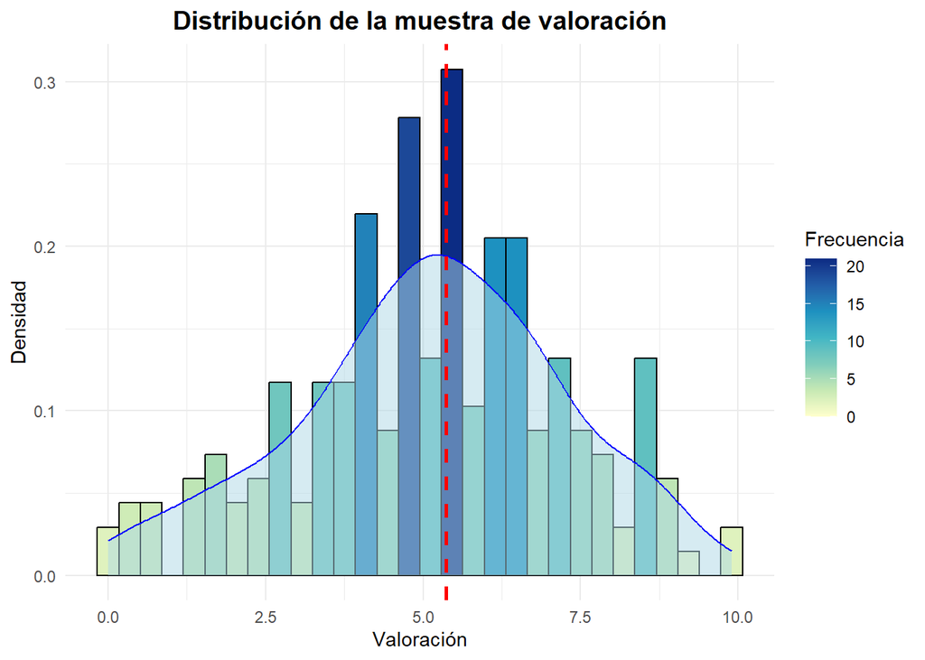

```r
sample_valor <- sample$valor

ggplot(data = data.frame(sample_valor), aes(x = sample_valor)) +
  geom_histogram(aes(y = after_stat(density), fill = after_stat(count)),
                 bins = 30, color = "black") +
  geom_density(alpha = 0.5, color = "blue", fill = "lightblue") +
  scale_fill_distiller(palette = "YlGnBu", direction = 1) + # Puedes cambiar la paleta aquí
  geom_vline(xintercept = media_media_sample, linetype = "dashed", color = "red", linewidth = 1) +
  theme_minimal() +
  labs(title = "Distribución de la muestra de valoración",
       x = "Valoración",
       y = "Densidad",
       fill = "Frecuencia") +
  theme(plot.title = element_text(hjust = 0.5, face = "bold", size = 14))
```

En el eje horizontal se representa la escala de valoración, que va de 0 a 10, donde 0 indica la peor opinión posible y 10 la mejor. En el eje vertical se observa la densidad, la cual refleja la proporción relativa de estudiantes que han asignado cada rango de puntuación.

La distribución de la muestra sugiere una valoración alrededor del 5, como se puede ver en la media de medias que se situa en 5.37, aunque con un grado de dispersión que invita a reflexionar sobre las posibles desigualdades en la calidad docente percibida.

Este resultado indica que, en términos generales, la percepción de la docencia por parte del estudiantado se sitúa ligeramente por encima del punto medio de la escala (0-10). Aunque no se trata de una valoración especialmente baja, tampoco refleja una opinión claramente positiva. En otras palabras, la media sugiere que el alumnado tiene una percepción regular o neutra, lo que podría interpretarse como una satisfacción parcial o incluso una cierta insatisfacción, dependiendo del contexto y de las expectativas del estudiantado.

# Escenario 2

Ahora, se divide a la población en estratos (cada grado es un estrato: ADE, BIA, DRECO, etc.) para decidir cuántos estudiantes seleccionar en cada estrato según diferentes criterios de asignación.

Se crea una función para calcular tamaños de muestra según el tipo de asignación:

- **Igual**: Mismo número de muestreados en cada estrato
- **Proporcional**: Proporcional al número de estudiantes en cada grado
- **Mínima varianza**: Se selecciona el número de muestreados de forma que se minimice la varianza

```r
tamanos_muestra <- function(n, Wh, afij, sigmas) {
  # n es el tamaño total de la muestra
  # v es el vector de tamaños poblacionales de cada estrato
  # afij es una variable que solo toma 3 valores:
  # c("igual", "proporcional", "mínima") para decidir la estrategia

  ns <- numeric(length(Wh))
  L <- length(Wh)

  if (afij == "igual") {
    ns <- rep(n / length(Wh), length(Wh))
    return(ns)
  }

  if (afij == "proporcional") {
    ns <- n * Wh
    return(ns)
  }

  if (afij == "mínima") {

    ns <- (n * Wh * sigmas$sigma_h) / sum(Wh * sigmas$sigma_h)

    return(ns)
  }
    stop("Estrategia no válida. Use 'igual', 'proporcional' o 'mínima'.")
}

n <- 200 # Tamaño de la muestra

wh <- c("ADDR"=1500/22000, "ADE"= 5000/22000, "BIA"=1000/22000, "DRECO"=2000/22000, "ECO"=2500/22000, "FIC"=3000/22000,"GIB"=1000/22000, "TADE"=2500/22000, "TUR"=3500/22000) # Tamaños poblacionales de los estratos

afij <- "mínima" #igual / proporcional / mínima

sigmas <- dat.fp %>%
  group_by(grado) %>%
  summarise(sigma_h = sd(valor, na.rm = TRUE)) %>%
  arrange(grado)

# tamaños muestrales para cada estrato
resultados <- tamanos_muestra(n, wh, afij, sigmas)
print(format(resultados, scientific = FALSE))
```

```
       ADDR         ADE         BIA       DRECO         ECO         FIC
"14.327955" "50.639618" " 8.838711" "12.714163" "21.668532" "23.275621"
        GIB        TADE         TUR
" 5.412213" "27.691355" "35.431831"
```

Para utilizar esta función se le pasan cuatro argumentos:

- n = tamaño total muestra
- Wh = proporciones poblacionales de cada grado, es decir, sus pesos
- afij = tipo de asignación, que puede ser igual, proporcional o mínima
- sigmas = desviaciones típicas de las valoraciones por grado

Esta función es muy útil a la hora de seleccionar muestras, lo cual se elabora a continuación.

# Escenario 3

Se realiza el muestreo en la práctica creando la función `m.estr`, que inicializa un dataframe vacío, y para cada grado (estrato), selecciona usando la función anterior `tamanos_muestra` el tamaño de muestra para ese estrato, y junta cada muestra de estrato en el dataframe que devuelve la muestra total.

```r
est.nam <- c("ADDR", "ADE",  "BIA", "DRECO", "ECO", "FIC", "GIB", "TADE", "TUR")

m.estr <- function(dat.fp, est.nam, est.size){

  d <- dat.fp[0,0] #inicializamos la función

  for (i in 1:length(est.nam)) {
    s <- dat.fp[dat.fp$grado==est.nam[i],]
    d <- rbind(d, sample_n(s, round(est.size[i])))

  }

  return(d)

}
```

Con cada tipo de asignación (igual, proporcional, mínima), se calcula la media de cada grado y la media ponderada teniendo en cuenta los tamaños poblacionales `wh` calculados previamente en la función `weighted.mean`.

```r
resultados_igual <- tamanos_muestra(n, wh, "igual", sigmas)

muestra_igual <- m.estr(dat.fp, est.nam, resultados_igual)

medias_igual <- muestra_igual %>%
  group_by(grado) %>%
  summarise(media = mean(valor, na.rm = TRUE)) %>%
  arrange(grado)

media_media_igual <- weighted.mean(medias_igual$media, wh)
round(media_media_igual,2)
```

```
[1] 5.03
```

```r
resultados_proporcional <- tamanos_muestra(n, wh, "proporcional", sigmas)

muestra_proporcional <- m.estr(dat.fp, est.nam, resultados_proporcional)

medias_proporcional <- muestra_proporcional %>%
  group_by(grado) %>%
  summarise(media = mean(valor, na.rm = TRUE)) %>%
  arrange(grado)

media_media_proporcional <- weighted.mean(medias_proporcional$media, wh)
round(media_media_proporcional,2)
```

```
[1] 5.37
```

```r
resultados_minima <- tamanos_muestra(n, wh, "mínima", sigmas)

muestra_minima <- m.estr(dat.fp, est.nam, resultados_minima)

medias_minima <- muestra_minima %>%
  group_by(grado) %>%
  summarise(media = mean(valor, na.rm = TRUE)) %>%
  arrange(grado)

media_media_minima <- weighted.mean(medias_minima$media, wh)
round(media_media_minima,2)
```

```
[1] 5.27
```

# Escenario 4

Por último, se realiza una postestrificación, que es un ajuste que se realiza después de seleccionar la muestra, para corregir el hecho de que los grados no estaban representados de manera proporcional al principio.

Se recalculan las medias de valoración por grado, la media ponderada considerando el tamaño real de cada grado.

```r
medias_postestr <- sample %>%
  group_by(grado) %>%
  summarise(media = mean(valor, na.rm = TRUE)) %>%
  arrange(grado)

media_media_postestr <- weighted.mean(medias_postestr$media, wh)
round(media_media_postestr,2)
```

```
[1] 5.14
```

Finalmente se comparan las medias:

```r
tabla <- data.frame(
  Estimaciones = c("media", "nADE", "nBIA", "nTUR", "nGIB", "nECO", "nFIC", "nADDR", "nDRECO", "nTADE"),
  MAS=c(round(media_media_sample,2), round(medias_sample$media,2)),
  MEAi=c(round(media_media_igual,2), round(medias_igual$media,2)),
  MEAp=c(round(media_media_proporcional,2), round(medias_proporcional$media,2)),
  MEAm=c(round(media_media_minima,2), round(medias_minima$media,2)),
  Post.=c(round(media_media_postestr,2), round(medias_postestr$media,2))

)
```

```r
tabla$Media_Fila <- round(rowMeans(tabla[, 2:ncol(tabla)], na.rm = TRUE),2)

kable(tabla, caption = "Comparación de medias por método de muestreo")
```

Comparación de medias por método de muestreo

| Estimaciones | MAS | MEAi | MEAp | MEAm | Post. | Media_Fila |
| --- | --- | --- | --- | --- | --- | --- |
| media | 5.37 | 5.03 | 5.37 | 5.27 | 5.14 | 5.24 |
| nADE | 6.90 | 7.56 | 6.68 | 7.30 | 6.90 | 7.07 |
| nBIA | 5.47 | 5.03 | 5.72 | 5.59 | 5.47 | 5.46 |
| nTUR | 5.28 | 5.51 | 5.47 | 6.30 | 5.28 | 5.57 |
| nGIB | 4.78 | 5.18 | 4.91 | 4.82 | 4.78 | 4.89 |
| nECO | 5.57 | 6.19 | 5.84 | 5.51 | 5.57 | 5.74 |
| nFIC | 3.99 | 3.74 | 4.18 | 3.67 | 3.99 | 3.91 |
| nADDR | 7.13 | 7.61 | 7.71 | 7.70 | 7.13 | 7.46 |
| nDRECO | 4.58 | 4.15 | 5.05 | 4.80 | 4.58 | 4.63 |
| nTADE | 4.61 | 3.87 | 4.76 | 4.77 | 4.61 | 4.52 |

En conclusión, el muestreo estratificado proporcional y el muestreo aleatorio simple nos dieron medias similares. El muestreo estratificado mínima varianza logra una mejor precisión (tiene en cuenta la variabilidad interna de los estratos). La postestratificación ajusta las posibles diferencias de representación en la muestra original.

La calidad de la docencia, según la muestra de estudiantes encuestados, se percibe como regular, con medias de valoración alrededor de 5 sobre 10. Aunque no se observa una satisfacción alta, tampoco hay un claro rechazo. Esto sugiere un nivel de satisfacción moderado, y podría orientar a la Facultad hacia estrategias de mejora de la calidad docente, basadas en encuestas más específicas por grado.

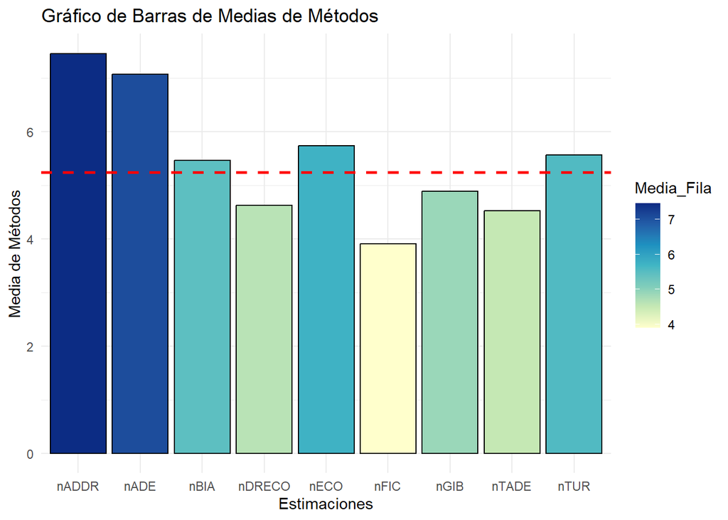

```r
ggplot(tabla[-1, ], aes(x = Estimaciones, y = Media_Fila, fill = Media_Fila)) +
  geom_col(color = "black") +
  scale_fill_distiller(palette = "YlGnBu", direction = 1) +
  geom_hline(yintercept = tabla$Media_Fila[1], linetype = "dashed", color = "red", linewidth = 1) +
  labs(
    title = "Gráfico de Barras de Medias de Métodos",
    x = "Estimaciones",
    y = "Media de Métodos"
  ) +
  theme_minimal()
```

La situación de BIA destaca positivamente considerando su reciente implementación, y sugiere una acogida inicial por encima de la media. Esta información resulta clave para orientar mejoras docentes específicas, adaptadas al perfil y necesidades de cada titulación.

Además, este estudio ha demostrado cómo diferentes métodos de muestreo (MAS, estratificado, postestratificado) pueden afectar ligeramente las estimaciones de la media. Y cómo aplicar técnicas como la postestratificación mejora la representatividad de la muestra respecto a la población real, lo que refuerza la validez de las conclusiones.

Mientras que el muestreo aleatorio simple puede resultar adecuado en contextos homogéneos, en poblaciones con marcada heterogeneidad como la analizada, los métodos estratificados, especialmente con afijación proporcional o mínima, y la postestratificación, ofrecen estimaciones más precisas y representativas. La comparación entre ellos pone de manifiesto la importancia de considerar tanto la estructura poblacional como la variabilidad interna de los grupos al diseñar estudios muestrales en contextos educativos o sociales.